```python
#pour centrer les figures
from IPython.display import Image, display, HTML

CSS = """
.output {
    align-items: center;
}
"""

HTML('<style>{}</style>'.format(CSS))
```

# CODE PyODHeaN commenté - *P1k1C2 - NLP*

Auteur: Hugo Viot

Création: 27/06/2018

Mis à jour le: 04/12/2018

Commit: 286e8a4c19

hviot@nobatek.inef4.com

### Import de librairie / Création d'un modèle

```python
# Import
from pyomo.environ import *
from math import pi

# Creation d'un cas d'étude
model = ConcreteModel()
```

## INDICES

```python
#-----------------------------------------------------------------------------------------#
########################################### SET ###########################################
#-----------------------------------------------------------------------------------------#

# Définition des indices
model.i = Set(initialize=['P1'], doc='indice des noeuds producteurs')
model.j = Set(initialize=['C1','C2'], doc='indice des noeuds consommateurs')
model.o = Set(initialize=['C1','C2'], doc='indice des noeuds consommateurs')
model.k = Set(initialize=['k1'], doc='indice technologie de production')
```

## PARAMETRES

### Paramètres généraux

```python
#-----------------------------------------------------------------------------------------#
######################################### PARAMETER #######################################
#-----------------------------------------------------------------------------------------#

# Définition des paramètres dépendant de la taille du problème
model.C_tr_unit = Param(initialize=800, doc='coût unitaire de tranchee aller-retour (€/ml)')
model.period = Param(initialize=5808, doc='durée de fonctionnement annuelle du RCU (h)')
model.annee = Param(initialize=15, doc='duree d\'amortissement (année)')
model.x_P = Param(model.i, initialize={'P1':0}, doc='abscisse d\'un noeud producteur (m)')
model.z_P = Param(model.i, initialize={'P1':0}, doc='ordonnée d\'un noeud producteur (m)')
model.C_Hprod_unit = Param(model.k,initialize={'k1':800}, doc='coût unitaire  de la chaudiere installée (€/kW)')
model.C_heat_unit = Param(model.k,initialize={'k1':0.08}, doc='coût unitaire de la chaleur suivant l\'énergie de la technologie employee et la periode selon inflation (€/kWh)')
model.Eff = Param(model.k,initialize={'k1':0.9}, doc='rendement de la technologie k (%)')
model.rate_i = Param(model.k,initialize={'k1':0.04}, doc='inflation de l\'énergie liée à la technologie k (%)')
model.rate_i_pump = Param(initialize=0.04, doc='inflation du coût de l\'électricite pour le pompage (%)')
model.x_C = Param(model.j, initialize={'C1':60,'C2':0}, doc='abscisse d\'un noeud consommateur (m)')
model.z_C = Param(model.j, initialize={'C1':40,'C2':40}, doc='ordonnée d\'un noeud consommateur (m)')
model.H_req = Param(model.j, initialize={'C1':80,'C2':80}, doc='besoin de chaleur (kW)')
model.T_req_out = Param(model.j, initialize={'C1':60,'C2':60}, doc='température entree reseau secondaire du consommateur (°C)')
model.T_req_in = Param(model.j, initialize={'C1':80,'C2':80}, doc='température retour reseau secondaire du consommateur (°C)')
```

### Quelle technologie possiblement associées à chaque production ?

Revient à écrire une matrice ${M_{techno}}$ telle que $dim(M_{techno})= i\times k$ :

$\mathrm {M_{techno}} (P_{i},k_{k}) = \begin{array}{cc} \begin{array}{cccc} k_{1} & k_{2} & \dots & k_{k} \end{array} & \\ \left(\begin{array}{cccc} Y_{11} & Y_{12} & \dots & Y_{1k} \\ Y_{21} & Y_{22} & \dots & Y_{2k} \\ \vdots & \vdots & \vdots & \vdots \\ Y_{i1} & Y_{i2} & \dots & Y_{ik} \end{array}\right)& \begin{array}{c} P_{1}\\ P_{2}\\ \vdots \\P_{i} \end{array} \end{array}$

Ce sont les technologies possibles pour chaque site producteur mais à l'issue de l'optimisation elles peuvent être conservées ou non. En revanche ici il s'agit de l'algorithme NLP donc la configuration est fixée.  
Dans cet exemple il n'y a qu'une seule production (P1) associée à une seule technologie (k1):

$M_{techno}= (1)$

```python
# Quelle technologie associée à chaque production ?
table_Y_P = {
    ('P1',  'k1') : 1,
    }

model.Y_P = Param(model.i, model.k, initialize=table_Y_P, doc='Existence techno k au lieu de production Pi')
```

### Initialisation des canalisations entre producteurs et consommateurs

Revient à écrire deux matrices ${M_{PC}}$ et ${M_{CP}}$ telles que $dim(M_{PC})= i\times j$ et $dim(M_{CP})= j\times i$ :

$\mathrm {M_{PC}} (P_{i},C_{j}) = \begin{array}{cccc} \begin{array}{cccc} C_{1} & C_{2} & \dots & C_{j} \end{array} & \\ \left(\begin{array}{cccc} Y_{11} & Y_{12} & \dots & Y_{1j} \\ Y_{21} & Y_{22} & \dots & Y_{2j} \\ \vdots & \vdots & \vdots & \vdots \\ Y_{i1} & Y_{i2} & \dots & Y_{ij} \end{array}\right)& \begin{array}{c} P_{1}\\ P_{2}\\ \vdots \\P_{i} \end{array} \end{array}$

${M_{CP}={M^{T}_{PC}}}$

On ne travaille qu'avec des canalisations aller-retour dans la même tranchée d'où l'équation ${M_{CP}={M^{T}_{PC}}}$  
Il s'agit juste d'une possibilité d'initialisation, l'optimisation teste ensuite toutes les valeurs possibles de cette matrice et conserve le cas optimal. En revanche ici il s'agit de l'algorithme NLP donc la configuration est fixée. Dans cet exemple:

$\mathrm {M_{PC}} = \begin{array}{cc} \left(\begin{array}{cccc} 1 & 0 \\ \end{array}\right)& \end{array}$

$\mathrm {M_{CP}} = \begin{array}{cc} \left(\begin{array}{cccc} 1 \\ 0 \\ \end{array}\right)& \end{array}$

```python
# Initialisation des canalisations entre producteurs et consommateurs
table_Y_linePC = {
    ('P1',  'C1') : 1,
    ('P1',  'C2') : 0,
    }

model.Y_linePC = Param(model.i, model.j, initialize=table_Y_linePC, doc='Existence canalisation PC')


# Initialisation des canalisations entre consommateurs et producteurs
table_Y_lineCP = {
    ('C1',  'P1') : 1,
    ('C2',  'P1') : 0,
    }
model.Y_lineCP = Param(model.j, model.i, initialize=table_Y_lineCP, doc='Existence canalisation CP')
```

### Initialisation des canalisations entre consommateurs

Revient à écrire deux matrices ${M_{CC_{parallel}}}$ et ${M_{CC_{return}}}$ telles que $dim(M_{CC_{parallel}})= j\times o$ et $dim(M_{CC_{return}})= o\times j$ :

$\mathrm {M_{CC_{parallel}}} (C_{j},C_{o}) = \begin{array}{cc} \begin{array}{cccc} C_{1} & C_{2} & \dots & C_{o} \end{array} & \\ \left(\begin{array}{cccc} Y_{11} & Y_{12} & \dots & Y_{1i} \\ Y_{21} & Y_{22} & \dots & Y_{2i} \\ \vdots & \vdots & \vdots & \vdots \\ Y_{j1} & Y_{j2} & \dots & Y_{ji} \end{array}\right)& \begin{array}{c} C_{1}\\ C_{2}\\ \vdots \\C_{j} \end{array} \end{array}$

${M_{CC_{return}}}={M^{T}_{CC_{parralel}}}$

On ne travaille qu'avec des canalisations aller-retour dans la même tranchée d'où l'équation ${M_{CC_{return}}}={M^{T}_{CC_{parralel}}}$  
De plus un consommateur ne peut être relié à lui même donc $diag({M_{CC_{parralel}}})=diag({M_{CC_{return}}})=0$  
Ici il s'agit de l'algorithme NLP donc la configuration est fixée. Dans cet exemple:

$\mathrm {M_{CC_{parralel}}} = \begin{array}{cc} \left(\begin{array}{cccc} 0 & 1 \\ 0 & 0 \\ \end{array}\right)& \end{array}$

$\mathrm {M_{CC_{return}}} = \begin{array}{cc} \left(\begin{array}{cccc} 0 & 0 \\ 1 & 0 \\ \end{array}\right)& \end{array}$

```python
# Initialisation des canalisations entre consommateurs
## Aller
table_Y_lineCC_parallel = {
    ('C1',  'C1') : 0,
    ('C1',  'C2') : 1,
    ('C2',  'C1') : 0,
    ('C2',  'C2') : 0,
    }
model.Y_lineCC_parallel = Param(model.j, model.o, initialize=table_Y_lineCC_parallel, doc='Existence canalisation CC parallel')

## Retour
table_Y_lineCC_return = {
    ('C1',  'C1') : 0,
    ('C1',  'C2') : 0,
    ('C2',  'C1') : 1,
    ('C2',  'C2') : 0,
    }
model.Y_lineCC_return = Param(model.o, model.j, initialize=table_Y_lineCC_return, doc='Existence canalisation CC return')
```

### Définition des paramètres ne dépendant pas de la taille du problème

Description dans "doc" pour les paramètres dont la valeur est simplement déclarée.

```python
# Définition des paramètres ne dépendant pas de la taille du problème
## Valeur affectée
model.Eff_pump = Param(initialize=0.7, doc='rendement de la pompe pour le calcul du coût de pompage(%)')
model.T_hx_pinch = Param(initialize=5, doc='température de pincement minimum a l\'échangeur (°C)')
model.K_hx = Param(initialize=20, doc='coefficient global d\'échange (kW/m2.K)')
model.Cp = Param(initialize=4.196, doc='capacite thermique de l\'eau à 80°C (kJ/kg.K)')
model.C_pump_unit = Param(initialize=0.11, doc='coût unitaire de l\'électricite pour le pompage (€/kWh)')
model.mu = Param(initialize=0.000354, doc='viscosite de l\'eau a 80°C (Pa.s)')
model.rho = Param(initialize=974, doc='masse volumique de l\'eau a 20°C (kg/m3)')
model.alpha = Param(initialize=1.75, doc='exposant pour le calcul des pertes de charge et le calcul du coût de pompage')
model.beta = Param(initialize=-1.25, doc='exposant pour le calcul des pertes de charge et le calcul du coût de pompage')
model.C_pipe_unit_a = Param(initialize=0.3722, doc='coefficient directeur de la relation linéaire du coût de la canalisation selon le diamètre (ensemble tuyau+isolant)(€/m)')
model.C_pipe_unit_b = Param(initialize=12.48, doc='ordonnée à l\'origine de la relation linéaire du coût de la canalisationselon le diamètre (ensemble tuyau+isolant)(€)')
model.C_hx_unit_a = Param(initialize=5.3, doc='coefficient directeur du coût unitaire de l\'echangeur (€/kW )')
model.C_hx_unit_b = Param(initialize=5045, doc='ordonnee à l\'origine du coût unitaire de l\'echangeur (€)')
model.rate_a = Param(initialize=0.04, doc='taux d\'actualisation pour le calcul de l\'annuite des investissements initiaux')
model.T_ext = Param(initialize=15, doc='température extérieure pour le calcul des pertes thermiques de la canalisation')
model.lambda_insul = Param(initialize=0.03, doc='conductivite thermique de l\'isolant (W/m.K)')
model.lambda_soil = Param(initialize=1.4, doc='conductivite thermique du sol (W/m.K)')
model.z_pipe = Param(initialize=0.4, doc='hauteur de sol au dessus des canalisations pour le calcul des pertes thermiques (m)')
model.epsilon = Param(initialize=0.000000001, doc='chiffre infinitesimal utile pour éviter les erreurs de division par zero')
model.tk_insul = Param(initialize=0.0276, doc='épaisseur de l\'isolant autour de la canalisation (m)')
model.tk_pipe = Param(initialize=0.025, doc='épaisseur de metal dependant du diametre (m)')
model.DP_hx_unit = Param(initialize=20, doc='perte de charge dans un echangeur (kPa)')

## bornes
model.V_min = Param(initialize=0.1, doc='borne vitesse min, 0.1m/s d\'après Techniques de l\'Ingénieur (m/s)')
model.V_max = Param(initialize=3, doc='borne vitesse max, 3m/s d\'après Techniques de l\'Ingénieur (m/s)')
model.P_min = Param(initialize=120, doc='pression minimale en borne inférieure (kPa)')
model.P_max = Param(initialize=500, doc='pression max en borne supérieure (kPa)')
model.T_prod_out_max = Param(model.k,initialize={'k1':100}, doc='température max autorisée en sortie de chaudiere de la techno k (°C)')
model.T_prod_in_min = Param(model.k,initialize={'k1':30}, doc='température min autorisée en entree de chaudiere de la techno k (°C)')
model.Dint_max = Param(initialize=0.25, doc='diamètre interieur max du tuyau (m)')
model.Dint_min = Param(initialize=0.01, doc='diamètre interieur max du tuyau (m)')
model.Dist_max_autorisee = Param(initialize=1000, doc='distance max pour borner les longueurs de canalisations (m)')
```

#### Note sur le bigM: exemple avec H_inst_max

Un paramètre "bigM" est associé lorsqu'une variable est lié à une conditions d'existance $Yij$  
La méthode du bigM permet de n’ajouter une contrainte que lorsque la variable binaire est égale à 1 (dans ce cas, la double inégalités deviennent une égalité). Sinon, lorsque la variable binaire est nulle, comme la valeur de bigM est prise très grande, cette contrainte n’est jamais saturée.  
Par exemple si l'on souhaite une égalité de température au niveau d'un noeud d'un consommateur ssi ce consommateur est raccordé au réseau:  
$\left\{ \begin{array}{rcr} T_{1} \le T_{2}+bigM\times(1-Y) \\ T_{1} \ge T_{2}+bigM\times(1-Y) \\ \end{array} \iff -bigM\times(1-Y) \le T_{1}-T_{2} \le bigM\times(1-Y) \\ \right.$

Si le consommateur est raccordé: $Y=1$ et la double inégalité devient une égalité:  
$\left\{ \begin{array}{rcr} T_{1} \le T_{2} \\ T_{1} \ge T_{2} \\ \end{array} \iff 0 \le T_{1}-T_{2} \le 0 \iff T_{1}=T_{2} \\ \right.$

Si le consommateur n'est pas raccordé: $Y=0$ et la contraite est levée sur la température avec des bornes à une valeur très grande:  
$\left\{ \begin{array}{rcr} T_{1} \le T_{2}+bigM \\ T_{1} \ge T_{2}+bigM \\ \end{array} \iff -bigM \le T_{1}-T_{2} \le +bigM \iff T_{1} \ne T_{2} \\ \right.$

Pour chaque paramètre le schéma est toujours le même:

- calcul de sa valeur par une fonction
- déclaration du paramètre

La signification de chaque paramètre et mentionné en docstring ou "doc" si la description est courte.

```python
## Valeur calculée
def calcul_H_inst_max(model):
    """somme des puissances installées de toutes les sous-stations, correspond à la puissance maximale théorique appelée (cas exeptionnel)
    et donc sert de borne max pour la puissance à installer au niveau de la production"""
    return 1.5*sum(model.H_req[j] for j in model.j)
model.H_inst_max = Param(initialize=calcul_H_inst_max)

def calcul_H_inst_bigM(model):
    """BigM associé à la puissance maximale à installer à chaque production
    (valeur commune à toutes les productions potentielles)"""
    return 1000*sum(model.H_req[j] for j in model.j)
model.H_inst_bigM = Param(initialize=calcul_H_inst_bigM)

def calcul_gamma(model):
    """coefficient gamma pour le calcul des pertes de charges du réseau (à combattre par la pompe)
    pour en déduire la puissance de pompage et son coût"""
    return 100/70*((100/model.mu)**(-0.25))/(2*(model.rho**(0.75)))
model.gamma = Param(initialize=calcul_gamma)

def calcul_DistPC(model,i,j):
    """calcul des distances Euclidiennes (à vol d'oiseau) entre chaque producteurs et consommateurs,
    revient à écrire une matrice de dimension i x j contenant les distances,
    toutes les distances existent, que les producteurs-consommateurs soient reliés ou non après optimisation"""
    return ((model.x_C[j]-model.x_P[i])**2 + (model.z_C[j]-model.z_P[i])**2 )**(0.5)
model.Dist_PC = Param(model.i,model.j,initialize=calcul_DistPC)

def calcul_DistCC(model,j,o):
    """calcul des distances Euclidiennes (à vol d'oiseau) entre consommateurs,
    revient à écrire une matrice de dimension j x o contenant les distances donc les termes de la
    diagonale valent 0: on ne calcule pas une distance d'un consommateurs à lui même,
    toutes les distances existent, que les producteurs-consommateurs soient reliés ou non après optimisation"""
    if j != o:
        return ((model.x_C[j]-model.x_C[o])**2 + (model.z_C[j]-model.z_C[o])**2 )**(0.5)
    else:
        return 0
model.Dist_CC = Param(model.j,model.o,initialize=calcul_DistCC)

model.Dist_bigM = Param(initialize=model.Dist_max_autorisee)
```

#### Note sur les taux d'inflation et d'actualisation

Facteurs utilisés afin de tenir compte de l’importance du temps dans les dépenses. Ces facteurs dépendent de l'inflation $r_{i}$ et du taux d'actualisation $r_{a}$.

- investissements (capex): dépendent du taux d'actualisation, en effet il ne suffit pas de diviser l’investissement par la durée d’amortissement pour obtenir une annuité. 100 € aujourd’hui n’ont pas la même valeur que 100 € dans 30 ans. Par exemple si on compare une somme V0 de 100€ à l’année de référence, dans 30 ans cette somme représentera 324 € (avec $r_{a}=4\%$). C’est avec cette équation que l’investissement initial du réseau de chaleur peut être comparé avec la somme des dépenses opérationnelles à l’année N.
- coût opérationnels (opex): dépendent de l'inflation et du taux d'actualisation, le coût de la chaleur et de l’électricité de pompage augmentent chaque années du fait de l’inflation du cours de l’énergie. C’est une hypothèse forte de l’analyse en coût global.

Le tableau ci-dessous résume le principe:

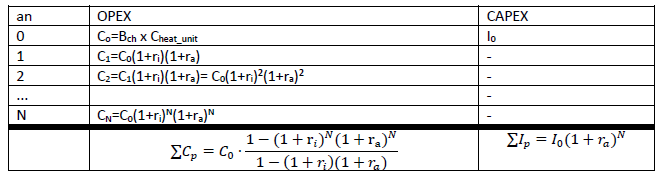

```python
Image(filename="Capture.png")
```

D'où  
$ f_{opex}=\frac{1-(1+r_i)^N(1+r_a)^N}{1-(1+r_i)(1+r_a)}$ et $ f_{capex}=(1+r_a)^N$

```python
def calcul_f_opex(model,k):
    """facteur multiplicateur des coûts operationnels permettant de tenir compte de la somme
     des dépenses annuelles actualisé et suivant l\'inflation de l\'energie et ce par technologie
     de production (électricité/gaz/biomasse/UIOM...)"""
    return (1-(1+model.rate_a)**model.annee*(1+model.rate_i[k])**model.annee)/(1-(1+model.rate_a)*(1+model.rate_i[k]))
model.f_opex = Param(model.k,initialize=calcul_f_opex)

def calcul_f_opex_pump(model):
    """idem pour la pompe, alimentée en électricité"""
    return (1-(1+model.rate_a)**model.annee*(1+model.rate_i_pump)**model.annee)/(1-(1+model.rate_a)*(1+model.rate_i_pump))
model.f_opex_pump = Param(initialize=calcul_f_opex_pump)

def calcul_f_capex(model):
    """facteur multiplicateur pour le calcul du coût d'investissement permettant de tenir compte
    du taux d'actualisation (mais pas d'inflation contraitement aux coûts opex)"""
    return (1+model.rate_a)**model.annee
model.f_capex = Param(initialize=calcul_f_capex)

def calcul_M_max(model):
    """débit maximal dans la canalisation, lié à V_max et Dint_max,
    s'applique à l'ensemble du réseau (productions, échangeurs en sous-station et conduites)"""
    return model.V_max*model.rho*pi*(model.Dint_max**2)/4
model.M_max = Param(initialize=calcul_M_max)

model.M_min = Param(initialize=0, doc='débit minimal dans la canalisation')

def calcul_M_bigM(model):
    """BigM associé au débit maximal pour l'optimisation des débits"""
    return 1000*model.M_max
model.M_bigM = Param(initialize=calcul_M_bigM)

def calcul_T_bigM(model):
    """BigM associé à la température maximale pour l'optimisation des régimes de température
    elle vaut la température de départ maximale des technologies disponibles"""
    return max(model.T_prod_out_max[k] for k in model.k)
model.T_bigM = Param(initialize=calcul_T_bigM)
```

### Bornes associés aux diamètres, résistances thermiques, températures

Description en docstring

#### Note sur le calcul des pertes thermiques

Les pertes thermiques dépendent du niveau de température du réseau ainsi que du débit de distribution et du diamètre des canalisations.  
La résistance thermique totale est la somme des résistances thermiques relative à l’isolation:  
$ R_{insul}=\frac{D_{int}}{2 \times\lambda_{insul}}. ln\left(\frac{D_{out}}{D_{int}}\right)$  
et du sol:  
$ R_{soil}=\frac{D_{int}}{2 \times\lambda_{soil}}. ln\left(\frac{4 .z_{pipe}}{D_{out}}\right)$  
Les résistances thermiques sont représentées sur la figure ci-dessous, celles barrées sont négligées:

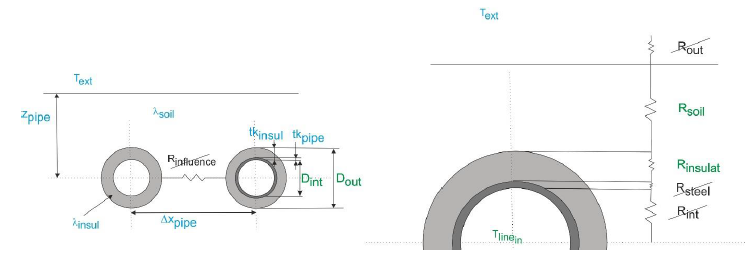

```python
Image(filename="Capture1.png")
```

```python
def calcul_Dout_max(model):
    """calcul du diamètre maximum de canalisation"""
    return model.Dint_max+model.tk_insul+model.tk_pipe
model.Dout_max = Param(initialize=calcul_Dout_max)

def calcul_Dout_min(model):
    """calcul du diamètre minimum de canalisation"""
    return model.Dint_min+model.tk_insul+model.tk_pipe
model.Dout_min = Param(initialize=calcul_Dout_min)

def calcul_R_insul_max(model):
    """calcul de la résistance maximale de l'épaisseur d'isolant"""
    return model.Dint_max/(2*model.lambda_insul)*log(model.Dout_max/model.Dint_max)
model.R_insul_max = Param(initialize=calcul_R_insul_max)

def calcul_R_insul_min(model):
    """calcul de la résistance minimale de l'épaisseur d'isolant"""
    return model.Dint_min/(2*model.lambda_insul)*log(model.Dout_min/model.Dint_min)
model.R_insul_min = Param(initialize=calcul_R_insul_min)

def calcul_R_soil_max(model):
    """calcul de la résistance maximale du sol au dessus des canalisations"""
    return model.Dint_max/(2*model.lambda_soil)*log(4*model.z_pipe/model.Dout_max)
model.R_soil_max = Param(initialize=calcul_R_soil_max)

def calcul_R_soil_min(model):
    """calcul de la résistance minimale du sol au dessus des canalisations"""
    return model.Dint_min/(2*model.lambda_soil)*log(4*model.z_pipe/model.Dout_min)
model.R_soil_min = Param(initialize=calcul_R_soil_min)

def calcul_R_tot_max(model):
    """calcul de la résistance totale maximale"""
    return model.R_insul_max+model.R_soil_max
model.R_tot_max = Param(initialize=calcul_R_tot_max)

def calcul_R_tot_min(model):
    """calcul de la résistance totale minimale"""
    return model.R_insul_min+model.R_soil_min
model.R_tot_min = Param(initialize=calcul_R_tot_min)

def calcul_T_init_min(model):
    """température minimale qui sert de borne inférieure pour les températures de départ/entrée (production, consommateur,
    échangeur, conduites, etc.). Il s'agit de la plus petite température parmis les températures minimales de retour des
    technologies de production et minimales de sortie des consommateurs"""
    return min( min(model.T_prod_in_min[k] for k in model.k) , min(model.T_req_in[j] for j in model.j) )
model.T_init_min = Param(initialize=calcul_T_init_min)

def calcul_T_init_max(model):
    """température maximale qui sert de borne supérieure pour les températures de retour/sortie (production, consommateur,
    échangeur, conduites, etc.). Il s'agit de la plus grande température parmis les températures maximales de départ des
    technologies de production et maximales d'entrée des consommateurs"""
    return max( max(model.T_prod_out_max[k] for k in model.k) , max(model.T_req_out[j] for j in model.j) )
model.T_init_max = Param(initialize=calcul_T_init_max)
```

### Matrice des distances

```python
## Distances
table_L_PC = {
    ('P1',  'C1') : 10,
    ('P1',  'C2') : 0,
    }

model.L_PC = Param(model.i, model.j, initialize=table_L_PC, doc='matrice des longueurs de canalisations')

table_L_CP = {
    ('C1',  'P1') : 10,
    ('C2',  'P1') : 0,
    }

model.L_CP = Param(model.j, model.i, initialize=table_L_CP, doc='matrice des longueurs de canalisations')

table_L_CC_parallel = {
    ('C1',  'C1') : 0,
    ('C1',  'C2') : 100,
    ('C2',  'C1') : 0,
    ('C2',  'C2') : 0,
    }

model.L_CC_parallel = Param(model.j, model.o, initialize=table_L_CC_parallel, doc='matrice des longueurs de canalisations')

table_L_CC_return = {
    ('C1',  'C1') : 0,
    ('C1',  'C2') : 0,
    ('C2',  'C1') : 100,
    ('C2',  'C2') : 0,
    }

model.L_CC_return = Param(model.o, model.j, initialize=table_L_CC_return, doc='matrice des longueurs de canalisations')
```

## VARIABLES

### Définitions des variables

Description en docstring

#### Note sur le notation utilisées

- PC: c'est la section de conduite entre la production et la première biffurcation qui dessert le premier consommateur
- CP: c'est la conduite de retour associée = mélange des retours de tous les consommateurs (CC_return)
- CC_parallel: l'ensemble des conduites desservant les sous stations après la première biffurcation
- CC_return: ensemble des conduites de retour

```python
#-----------------------------------------------------------------------------------------#
######################################### VARIABLE ########################################
#-----------------------------------------------------------------------------------------#

# Définition des variables
## vitesses
model.V_linePC = Var(model.i, model.j,initialize=(model.V_min+model.V_max)/2,bounds=(0,model.V_max), doc='vitesses conduites producteurs-consommateurs = ALLER')
model.V_lineCP = Var(model.j, model.i,initialize=(model.V_min+model.V_max)/2,bounds=(0,model.V_max), doc='vitesses conduites consommateurs-producteurs = RETOUR')
model.V_lineCC_parallel = Var(model.j, model.o,initialize=(model.V_min+model.V_max)/2,bounds=(0,model.V_max), doc='vitesses conduites consommateurs-consommateurs ALLER')
model.V_lineCC_return = Var(model.o, model.j,initialize=(model.V_min+model.V_max)/2,bounds=(0,model.V_max), doc='vitesses conduites consommateurs-consommateurs RETOUR')

## Diamètres
model.Dint_PC = Var(model.i, model.j,initialize=(model.Dint_min+model.Dint_max)/2,bounds=(model.Dint_min,model.Dint_max), doc='diamètres intérieurs conduites producteurs-consommateurs = ALLER')
model.Dint_CP = Var(model.j, model.i,initialize=(model.Dint_min+model.Dint_max)/2,bounds=(model.Dint_min,model.Dint_max), doc='diamètres intérieurs conduites consommateurs-producteurs = RETOUR')
model.Dint_CC_parallel = Var(model.j, model.o,initialize=(model.Dint_min+model.Dint_max)/2,bounds=(model.Dint_min,model.Dint_max), doc='diamètres intérieurs conduites consommateurs-consommateurs ALLER')
model.Dint_CC_return = Var(model.o, model.j,initialize=(model.Dint_min+model.Dint_max)/2,bounds=(model.Dint_min,model.Dint_max), doc='diamètres intérieurs conduites consommateurs-consommateurs RETOUR')
model.Dout_PC = Var(model.i, model.j,initialize=(model.Dint_min+model.Dint_max)/2,bounds=(model.Dint_min,model.Dint_max), doc='diamètres extérieurs conduites producteurs-consommateurs = ALLER')
model.Dout_CP = Var(model.j, model.i,initialize=(model.Dint_min+model.Dint_max)/2,bounds=(model.Dint_min,model.Dint_max), doc='diamètres extérieurs conduites consommateurs-producteurs = RETOUR')
model.Dout_CC_parallel = Var(model.j, model.o,initialize=(model.Dint_min+model.Dint_max)/2,bounds=(model.Dint_min,model.Dint_max), doc='diamètres extérieurs conduites consommateurs-consommateurs ALLER')
model.Dout_CC_return = Var(model.o, model.j,initialize=(model.Dint_min+model.Dint_max)/2,bounds=(model.Dint_min,model.Dint_max), doc='diamètres extérieurs conduites consommateurs-consommateurs RETOUR')

## Débits
model.M_linePC = Var(model.i,model.j,initialize=model.M_min,bounds=(model.M_min,model.M_max), doc='debit entre un noeud P(i) et C(j) (kg/s)')
model.M_lineCP = Var(model.j,model.i,initialize=model.M_min,bounds=(model.M_min,model.M_max), doc='debit entre un noeud C(j) et P(i) (kg/s)')
model.M_prod = Var(model.i,model.k,initialize=model.M_min,bounds=(model.M_min,model.M_max), doc='debit de la techno k(k) dans P(i) (kg/s)')
model.M_prod_tot = Var(model.i,initialize=model.M_min,bounds=(model.M_min,model.M_max), doc='debit dans P(i) = somme des débits des technos k(k) (kg/s)')
model.M_hx = Var(model.j,initialize=model.M_min,bounds=(model.M_min,model.M_max), doc='debit dans l\'échangeur de C(j) côté primaire (kg/s)')
model.M_supply = Var(model.j,initialize=model.M_min,bounds=(model.M_min,model.M_max), doc='debit avant l\'échangeur de C(j); différent de M_hx seulement si cascade autorisée (kg/s)')
model.M_lineCC_parallel = Var(model.j,model.o,initialize=model.M_min,bounds=(model.M_min,model.M_max), doc='debit entre un noeud C(j) et C(o) - ALLER (kg/s)')
model.M_lineCC_return = Var(model.o,model.j,initialize=model.M_min,bounds=(model.M_min,model.M_max), doc='debit entre un noeud C(o) et C(j) - RETOUR (kg/s)')
model.M_return = Var(model.j,initialize=model.M_min,bounds=(model.M_min,model.M_max), doc='debit après l\'échangeur au noeud C(j); différent de M_hx seulement si cascade (kg/s)')

## Températures
model.T_prod_in = Var(model.i,model.k,initialize=model.T_init_min,bounds=(model.T_init_min,model.T_init_max), doc='température de sortie de la technologie k à la production i (°C)')
model.T_prod_tot_in = Var(model.i,initialize=model.T_init_min,bounds=(model.T_init_min,model.T_init_max), doc='température de sortie de la production i = mélange des k technologies (°C)')
model.T_prod_out = Var(model.i,model.k,initialize=model.T_init_min,bounds=(model.T_init_min,model.T_init_max), doc='température de retour de la technologie k à la production i = température de retour à la production i (°C)')
model.T_prod_tot_out = Var(model.i,initialize=model.T_init_min,bounds=(model.T_init_min,model.T_init_max), doc='température de retour à la production i (°C)')
model.T_linePC_in = Var(model.i, model.j,initialize=model.T_init_min,bounds=(model.T_init_min,model.T_init_max), doc='température de départ de la production i (°C)')
model.T_linePC_out = Var(model.i, model.j,initialize=model.T_init_min,bounds=(model.T_init_min,model.T_init_max), doc='température d\'entrée dans le premier noeud = température de départ de la production i - pertes (°C)')
model.T_lineCP_in = Var(model.j, model.i,initialize=model.T_init_min,bounds=(model.T_init_min,model.T_init_max), doc='température de départ du dernier noeud (°C)')
model.T_lineCP_out = Var(model.j, model.i,initialize=model.T_init_min,bounds=(model.T_init_min,model.T_init_max), doc='température de retour à la production i = température de départ du dernier noeud - pertes (°C)')
model.T_hx_in = Var(model.j,initialize=model.T_init_min,bounds=(model.T_init_min,model.T_init_max), doc='température d\'entrée dans l\'échangeur (°C)')
model.T_hx_out = Var(model.j,initialize=model.T_init_min,bounds=(model.T_init_min,model.T_init_max), doc='température de sortie de l\'échangeur (°C)')
model.T_supply = Var(model.j,initialize=model.T_init_min,bounds=(model.T_init_min,model.T_init_max), doc='température avant l\'échangeur de C(j) = T_hx_in (°C)')
model.T_lineCC_parallel_in = Var(model.j, model.o,initialize=model.T_init_min,bounds=(model.T_init_min,model.T_init_max), doc='température de départ au noeud C(j) - ALLER (°C)')
model.T_lineCC_parallel_out = Var(model.j, model.o,initialize=model.T_init_min,bounds=(model.T_init_min,model.T_init_max), doc='température d\'arrivée au noeud C(o) - ALLER (°C)')
model.T_lineCC_return_in = Var(model.o, model.j,initialize=model.T_init_min,bounds=(model.T_init_min,model.T_init_max), doc='température de départ au noeud C(o) - RETOUR (°C)')
model.T_lineCC_return_out = Var(model.o, model.j,initialize=model.T_init_min,bounds=(model.T_init_min,model.T_init_max), doc='température d\'arrivée au noeud C(j) - RETOUR (°C)')
model.T_return = Var(model.j,initialize=model.T_init_min,bounds=(model.T_init_min,model.T_init_max), doc='température après l\'échangeur de C(j) = T_hx_out (°C)')
```

#### Note sur les échangeurs

Le DTLM permet de calculer la puissance de l'échangeur selon les températures au primaire et secondaire:  
$ H_{hx}=K_{hx}.A_{hx}.DTLM $  
avec  
$ DTLM=\frac{DT1-DT2}{ln\left(\frac{DT1}{DT2}\right)} \approx [DT1\times DT2\times\frac{1}{2}\times(DT1+DT2)]^\frac{1}{3} $

Avec $DT1$ et $DT2$ définies comme:

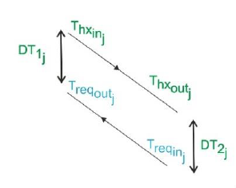

```python
Image(filename="Capture2.png")
```

```python
## Echangeur
model.DTLM = Var(model.j,initialize=max(model.T_prod_out_max[k] for k in model.k), bounds=(0,max(model.T_prod_out_max[k] for k in model.k)), doc='Différence logarithmique de température à l’échangeur de chaleur (°C)')
model.DT1 = Var(model.j,initialize=model.T_hx_pinch, bounds=(model.T_hx_pinch,model.T_init_max), doc='Différence de température côté chaud = T_hx_in - T_req_out (°C)')
model.DT2 = Var(model.j,initialize=model.T_hx_pinch, bounds=(model.T_hx_pinch,model.T_init_max), doc='Différence de température côté froid = T_hx_out - T_req_in (°C)')

def A_hx_borne(model,j):
    return (model.H_req[j]/(model.K_hx*max(model.T_prod_out_max[k] for k in model.k)), 10*model.H_req[j]/(model.K_hx*max(model.T_prod_out_max[k] for k in model.k)))
def A_hx_init(model,j):
    return  model.H_req[j]/(model.K_hx*max(model.T_prod_out_max[k] for k in model.k))
model.A_hx = Var(model.j,initialize=A_hx_init,bounds=A_hx_borne, doc='surface de l\'échangeur pour chaque consommateur j, bornée par le pincement T_hx_pinch ==> cf calcul de A_hx_borne')

## Pressions pour le coût_pompage
model.P_pump = Var(model.i,initialize=0,bounds=(0,model.P_max), doc='Pressions de pompage (Pa)')

## Puissances installées
model.H_inst = Var(model.i,model.k,initialize=0,bounds=(0,model.H_inst_max), doc='Puissance installée à la production i pour la technologie k (kW)')
# model.H_hx = Var(model.j,bounds=(0,80,), doc='Puissance nominale de l\'échangeur du consommateur j')

def H_hx_borne(model,j):
    return (0,model.H_req[j])
model.H_hx = Var(model.j,initialize=0,bounds=H_hx_borne, doc='Puissance nominale de l\'échangeur du consommateur j')
```

#### Note sur les termes de la fonction coût

L’algorithme recherche la solution qui permet de minimiser une fonction coût prenant en compte :

- les coûts opérationnels (Opex) :
  - coût de pompages liés aux pertes de charges ($C_{pump}$)
  - coût de la chaleur à produire selon la nature de la source d’énergie à la production ($C_{heat}$)
- les coûts d’investissements (Capex) :
  - coût de l’unité de production ($C_{Hinst}$)
  - coût des échangeurs en sous-station ($C_{hx}$)
  - coût de la conduite incluant la tranchée et la fourniture de tuyaux pré-isolés ($C_{line}$)

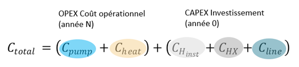

```python
Image(filename="Capture3.png")
```

```python
## Coûts
model.C_pump = Var(initialize=0,bounds=(0,None), doc='Coûts de pompage (€)')
model.C_heat = Var(initialize=0,bounds=(0,None), doc='Coût de la chaleur à produire (€)')
model.C_Hinst = Var(initialize=0,bounds=(0,None), doc='Coût d\'installation de la puissance à la production (€)')
model.C_hx = Var(initialize=0,bounds=(0,None), doc='Coût d\'installation des échangeurs en sous-station (€)')
model.C_line_tot = Var(initialize=0,bounds=(0,None), doc='Coût total de la canalisation = tranchée + tuyau pré-isolé (€) ')
model.C_pipe = Var(initialize=0,bounds=(0,None), doc='Coût des tuyau pré-isolés (€)')
model.C_tr = Var(initialize=0,bounds=(0,None), doc='Coût de tranchée (€)')

## Longueur du réseau
model.L_tot = Var(initialize=0,bounds=(0,None), doc='Longueur totale du réseau = longueur de tuyaux posés = 2 fois la longueur de tranchée car tuyau aller-retour')
```

## CONTRAINTES

### Diamètres

Description en docstring

```python
# Définition des diametres exterieurs = diametre interieur + epaisseur du tuyau et epaisseur isolant
def Def_Dout_PC_rule(model,i,j):
    """Diamètre des canalisations producteurs-consommateurs - ALLER"""
    return model.Dout_PC[i,j] == model.Dint_PC[i,j]+model.tk_pipe+model.tk_insul
model.Def_Dout_PC = Constraint(model.i,model.j,rule=Def_Dout_PC_rule)

def Def_Dout_CP_rule(model,j,i):
    """Diamètre de la canalisation producteurs-consommateurs - RETOUR"""
    return model.Dout_CP[j,i] == model.Dint_CP[j,i]+model.tk_pipe+model.tk_insul
model.Def_Dout_CP = Constraint(model.j,model.i,rule=Def_Dout_CP_rule)

def Def_Dout_CC_parallel_rule(model,j,o):
    """Diamètre des canalisations entre consommateurs - ALLER"""
    return model.Dout_CC_parallel[j,o] == model.Dint_CC_parallel[j,o]+model.tk_pipe+model.tk_insul
model.Def_Dout_CC_parallel = Constraint(model.j,model.o,rule=Def_Dout_CC_parallel_rule)

def Def_Dout_CC_return_rule(model,o,j):
    """Diamètre des canalisations entre consommateurs - RETOUR"""
    return model.Dout_CC_return[o,j] == model.Dint_CC_return[o,j]+model.tk_pipe+model.tk_insul
model.Def_Dout_CC_return = Constraint(model.o,model.j,rule=Def_Dout_CC_return_rule)
```

### Vitesses

Description en docstring

```python
# Existance des contraintes selon la valeur des variables binaires avec la méthode du bigM
## Débits
def Def_V_linePC_rule_bigM(model,i,j):
    """Inéquation du bigM sur le débit entre producteur et consommateur - ALLER"""
    valeur = model.V_linePC[i,j]*(model.rho*pi*model.Dint_PC[i,j]*model.Dint_PC[i,j]/4) - model.M_linePC[i,j]
    return - model.M_bigM*(1-model.Y_linePC[i,j]) <= valeur  <= model.M_bigM*(1-model.Y_linePC[i,j])
model.Def_V_linePC_bigM = Constraint(model.i,model.j,rule=Def_V_linePC_rule_bigM)

def Def_V_lineCP_rule_bigM(model,j,i):
    """Inéquation du bigM sur le débit entre consommateur et producteur - RETOUR"""
    valeur = model.V_lineCP[j,i]*(model.rho*pi*model.Dint_CP[j,i]*model.Dint_CP[j,i]/4) - model.M_lineCP[j,i]
    return - model.M_bigM*(1-model.Y_lineCP[j,i]) <= valeur <= model.M_bigM*(1-model.Y_lineCP[j,i])
model.Def_V_lineCP_bigM = Constraint(model.j,model.i,rule=Def_V_lineCP_rule_bigM)

def Def_V_lineCC_parallel_rule_bigM(model,j,o):
    """Inéquation du bigM sur le débit entre consommateurs - ALLER"""
    valeur = model.V_lineCC_parallel[j,o]*(model.rho*pi*model.Dint_CC_parallel[j,o]*model.Dint_CC_parallel[j,o]/4) - model.M_lineCC_parallel[j,o]
    return - model.M_bigM*(1-model.Y_lineCC_parallel[j,o]) <= valeur <= model.M_bigM*(1-model.Y_lineCC_parallel[j,o])
model.Def_V_lineCC_parallel_bigM = Constraint(model.j,model.o,rule=Def_V_lineCC_parallel_rule_bigM)

def Def_V_lineCC_return_rule_bigM(model,o,j):
    """Inéquation du bigM sur le débit entre consommateurs - RETOUR"""
    valeur = model.V_lineCC_return[o,j]*(model.rho*pi*model.Dint_CC_return[o,j]*model.Dint_CC_return[o,j]/4) - model.M_lineCC_return[o,j]
    return - model.M_bigM*(1-model.Y_lineCC_return[o,j]) <= valeur <= model.M_bigM*(1-model.Y_lineCC_return[o,j])
model.Def_V_lineCC_return_bigM = Constraint(model.o,model.j,rule=Def_V_lineCC_return_rule_bigM)

## Vitesses maximales et minimales
def Ex_V_linePC_max_rule(model,i,j):
    """Permet de definir une vitesse min/max que si la canalisation existe"""
    return model.V_linePC[i,j] <= model.V_max*model.Y_linePC[i,j]
model.Ex_V_linePC_max = Constraint(model.i,model.j,rule=Ex_V_linePC_max_rule)

def Ex_V_linePC_min_rule(model,i,j):
    """Permet de definir une vitesse min/max que si la canalisation existe"""
    return model.V_linePC[i,j] >= model.V_min*model.Y_linePC[i,j]
model.Ex_V_linePC_min = Constraint(model.i,model.j,rule=Ex_V_linePC_min_rule)

def Ex_V_lineCP_max_rule(model,j,i):
    """Permet de definir une vitesse min/max que si la canalisation existe"""
    return model.V_lineCP[j,i] <= model.V_max*model.Y_lineCP[j,i]
model.Ex_V_lineCP_max = Constraint(model.j,model.i,rule=Ex_V_lineCP_max_rule)

def Ex_V_lineCP_min_rule(model,j,i):
    """Permet de definir une vitesse min/max que si la canalisation existe"""
    return model.V_lineCP[j,i] >= model.V_min*model.Y_lineCP[j,i]
model.Ex_V_lineCP_min = Constraint(model.j,model.i,rule=Ex_V_lineCP_min_rule)

def Ex_V_lineCC_parallel_max_rule(model,j,o):
    """Permet de definir une vitesse min/max que si la canalisation existe"""
    return model.V_lineCC_parallel[j,o] <= model.V_max*model.Y_lineCC_parallel[j,o]
model.Ex_V_lineCC_parallel_max = Constraint(model.j,model.o,rule=Ex_V_lineCC_parallel_max_rule)

def Ex_V_lineCC_parallel_min_rule(model,j,o):
    """Permet de definir une vitesse min/max que si la canalisation existe"""
    return model.V_lineCC_parallel[j,o] >= model.V_min*model.Y_lineCC_parallel[j,o]
model.Ex_V_lineCC_parallel_min = Constraint(model.j,model.o,rule=Ex_V_lineCC_parallel_min_rule)

def Ex_V_lineCC_return_max_rule(model,o,j):
    """Permet de definir une vitesse min/max que si la canalisation existe"""
    return model.V_lineCC_return[o,j] <= model.V_max*model.Y_lineCC_return[o,j]
model.Ex_V_lineCC_return_max = Constraint(model.o,model.j,rule=Ex_V_lineCC_return_max_rule)

def Ex_V_lineCC_return_min_rule(model,o,j):
    """Permet de definir une vitesse min/max que si la canalisation existe"""
    return model.V_lineCC_return[o,j] >= model.V_min*model.Y_lineCC_return[o,j]
model.Ex_V_lineCC_return_min = Constraint(model.o,model.j,rule=Ex_V_lineCC_return_min_rule)
```

### Débits

Description en docstring

```python
# Definition de débits maximums et minimums si la canalisation existe, si la canalisations n'existe pas le débit est nul
def Ex_M_prod_max_rule(model,i,k):
    """Débit maximal pour chaque technologies k"""
    return model.M_prod[i,k] <= model.M_max*model.Y_P[i,k]
model.Ex_M_prod_max = Constraint(model.i,model.k,rule=Ex_M_prod_max_rule)

def Ex_M_prod_min_rule(model,i,k):
    """Débit minimal pour chaque technologies k"""
    return model.M_prod[i,k] >= model.M_min*model.Y_P[i,k]
model.Ex_M_prod_min = Constraint(model.i,model.k,rule=Ex_M_prod_min_rule)

def Ex_M_linePC_max_rule(model,i,j):
    """Débit maximal dans les canalisations entre producteurs et consommateurs - ALLER"""
    return model.M_linePC[i,j] <= model.M_max*model.Y_linePC[i,j]
model.Ex_M_linePC_max = Constraint(model.i,model.j,rule=Ex_M_linePC_max_rule)

def Ex_M_lineCP_max_rule(model,j,i):
    """Débit maximal dans les canalisations entre producteurs et consommateurs - RETOUR"""
    return model.M_lineCP[j,i] <= model.M_max*model.Y_lineCP[j,i]
model.Ex_M_lineCP_max = Constraint(model.j,model.i,rule=Ex_M_lineCP_max_rule)

def Ex_M_lineCC_parallel_max_rule(model,j,o):
    """Débit maximal dans les canalisations entre consommateurs - ALLER"""
    return model.M_lineCC_parallel[j,o] <= model.M_max*model.Y_lineCC_parallel[j,o]
model.Ex_M_lineCC_parallel_max = Constraint(model.j,model.o,rule=Ex_M_lineCC_parallel_max_rule)

def Ex_M_lineCC_return_max_rule(model,o,j):
    """Débit maximal dans les canalisations entre consommateurs - RETOUR"""
    return model.M_lineCC_return[o,j] <= model.M_max*model.Y_lineCC_return[o,j]
model.Ex_M_lineCC_return_max = Constraint(model.o,model.j,rule=Ex_M_lineCC_return_max_rule)
```

### Bilan de masse

Un bilan de masse est effectué à chaque noeud du modèle de producteur ou consommateur, le nom de la fonction fait référence au point correspondant repéré par une lettre sur les schémas ci dessous: *"def bilan+lettre*debit*.....(model,...)"*  
Description additionelles en docstring ou dans le code

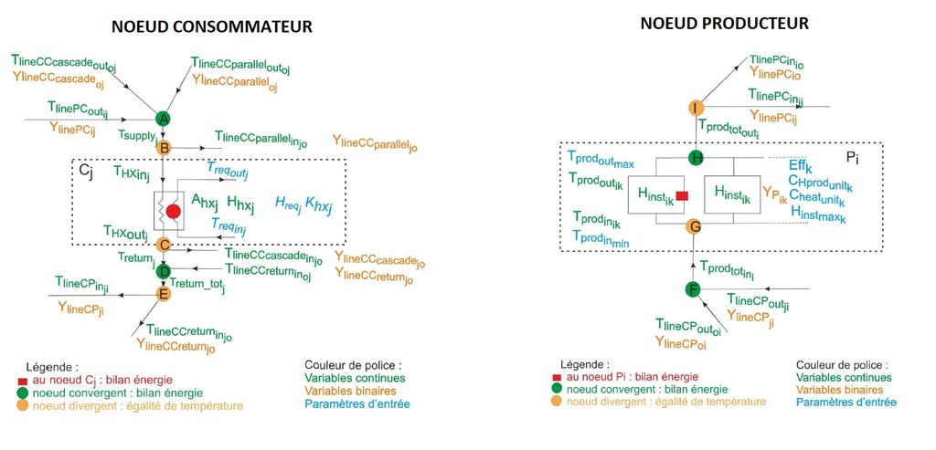

```python
Image(filename="Capture4.png")
```

```python
def bilanA_debit_supply_rule(model,j):
    """Bilan de masse au point A d'un noeud consommateur
    Un consommateur (M_supply) peut être alimenté par un producteur (M_linePC) ou un autre consommateur (M_lineCC_parallel)"""
    return sum(model.M_linePC[i,j] for i in model.i) + sum(model.M_lineCC_parallel[o,j] for o in model.o if o != j) == model.M_supply[j]
model.bilanA_debit_supply = Constraint(model.j,rule=bilanA_debit_supply_rule)

def bilanB_debit_hx_in_rule(model,j):
    """Bilan de masse au point B d'un noeud consommateur
    Seule une partie du débit (M_supply) alimente le consommateur (M_hx), le reste part vers une autre consommateur (M_lineCC_parallel),
    sauf s'il est en fin de réseau et dans ce cas M_supply = M_hx"""
    return model.M_supply[j] == model.M_hx[j] + sum(model.M_lineCC_parallel[j,o] for o in model.o if o != j)
model.bilanB_debit_hx_in = Constraint(model.j,rule=bilanB_debit_hx_in_rule)

def bilanD_debit_hx_out_rule(model,j):
    """Bilan de masse au point D d'un noeud consommateur
    Le débit (M_return) à chaque consommateur est composé du débit en sortie de l'échangeur (M_hx) et du débit de retour des autres
    consommateurs (M_lineCC_return), sauf s'il est en fin de réseau et dans ce cas M_return = M_hx"""
    return model.M_hx[j] + sum(model.M_lineCC_return[o,j] for o in model.o if o != j) == model.M_return[j]
model.bilanD_debit_hx_out = Constraint(model.j,rule=bilanD_debit_hx_out_rule)

def bilanE_debit_return_rule(model,j):
    """Bilan de masse au point E d'un noeud consommateur
    Après le point D, le débit (M_return) peut soit retourner vers la production (M_lineCP) soit vers un autre consommateur (M_lineCC_return)"""
    return model.M_return[j] == sum(model.M_lineCP[j,i] for i in model.i) + sum(model.M_lineCC_return[j,o] for o in model.o if o != j)
model.bilanE_debit_return = Constraint(model.j,rule=bilanE_debit_return_rule)

def bilanF_debit_prod_tot_in_rule(model,i):
    """Bilan de masse au point F d'un noeud producteur
    La débit de retour à la production (M_prod_tot) est égal au débit de retour du ou des derniers consommateurs par branche (M_lineCP)"""
    return sum(model.M_lineCP[j,i] for j in model.j) == model.M_prod_tot[i]
model.bilanF_debit_prod_tot_in = Constraint(model.i,rule=bilanF_debit_prod_tot_in_rule)

def bilanI_debit_prod_tot_out_rule(model,i):
    """Bilan de masse au point I d'un noeud producteur
    La débit de départ à la production (M_prod_tot) est égal aux débits partants vers les premiers consommateurs par branche (M_linePC)"""
    return model.M_prod_tot[i] == sum(model.M_linePC[i,j] for j in model.j)
model.bilanI_debit_prod_tot_out = Constraint(model.i,rule=bilanI_debit_prod_tot_out_rule)

def bilanGH_debit_prod_out_rule(model,i):
    """Bilan de masse aux points G et H d'un noeud producteur
    Le débit total partant/rentrant de la production i est égal à la somme des débit de chaque unité de production k associés"""
    return model.M_prod_tot[i] == sum(model.M_prod[i,k] for k in model.k)
model.bilanGH_debit_prod_out = Constraint(model.i,rule=bilanGH_debit_prod_out_rule)
```

### Bilan d'énergie ou égalité de température

Un bilan d'énergie est effectué si le noeud est convergeant (mélange de fluides à différentes températures). Si le noeud est divergeant, seuls les débits changent mais la température est la même avec et après la biffurcation.  
Description additionelles en docstring ou dans le code

```python
# BILAN D'ENERGIE ET EGALITE DE TEMPERATURE
def bilanA_H_supply_rule(model,j):
    """Bilan d'énergie au point A d'un noeud consommateur car point convergeant"""
    return model.M_supply[j]*model.T_supply[j] == (
    sum(model.M_linePC[i,j]*model.T_linePC_out[i,j] for i in model.i)
    + sum(model.M_lineCC_parallel[o,j]*model.T_lineCC_parallel_out[o,j] for o in model.o if o != j)
    )
model.bilanA_H_supply = Constraint(model.j,rule=bilanA_H_supply_rule)

def bilanB_T_hx_in_rule_bigM(model,j,o):
    """Première égalité de température au point B d'un noeud consommateur car point divergeant
    Tsupply = TlineCC_parallel
    Inéquation du bigM"""
    valeur = model.T_supply[j] - model.T_lineCC_parallel_in[j,o]
    return - model.T_bigM*(1-model.Y_lineCC_parallel[j,o]) <= valeur <= model.T_bigM*(1-model.Y_lineCC_parallel[j,o])
model.bilanB_T_hx_in_bigM = Constraint(model.j,model.o,rule=bilanB_T_hx_in_rule_bigM)

def bilanB2_T_hx_in_rule(model,j):
    """Deuxième égalité de température au point B d'un noeud consommateur car point divergeant
    Tsupply = Thx
    Pas de bigM car si le consommateur existe l'échangeur est forcément alimenté alors que la liaison avec
    un autre consommateur (TlineCC_parallel) n'existe pas forcément"""
    return model.T_hx_in[j] == model.T_supply[j]
model.bilanB2_T_hx_in = Constraint(model.j,rule=bilanB2_T_hx_in_rule)

def bilanD_H_hx_out_rule(model,j):
    """Bilan d'énergie au point D d'un noeud consommateur car point convergeant"""
    return model.M_hx[j]*model.T_hx_out[j]+sum(model.M_lineCC_return[o,j]*model.T_lineCC_return_out[o,j] for o in model.o if o != j) == model.M_return[j]*model.T_return[j]
model.bilanD_H_hx_out = Constraint(model.j,rule=bilanD_H_hx_out_rule)

def bilanE_T_return_rule_bigM(model,i,j):
    """Première égalité de température au point E d'un noeud consommateur car point divergeant
    Treturn = TlineCP
    Inéquation du bigM"""
    valeur = model.T_return[j] - model.T_lineCP_in[j,i]
    return - model.T_bigM*(1-model.Y_lineCP[j,i]) <= valeur <= model.T_bigM*(1-model.Y_lineCP[j,i])
model.bilanE_T_return_bigM = Constraint(model.i,model.j,rule=bilanE_T_return_rule_bigM)

def bilanE2_T_return_rule_bigM(model,o,j):
    """Deuxième égalité de température au point E d'un noeud consommateur car point divergeant
    Treturn = T_lineCC_return
    Inéquation du bigM"""
    valeur = model.T_return[o] - model.T_lineCC_return_in[o,j]
    return - model.T_bigM*(1-model.Y_lineCC_return[o,j]) <= valeur <= model.T_bigM*(1-model.Y_lineCC_return[o,j])
model.bilanE2_T_return_bigM = Constraint(model.o,model.j,rule=bilanE2_T_return_rule_bigM)

def bilanF_H_prod_tot_in_rule(model,i):
    """Bilan d'énergie au point F d'un noeud producteur car point convergeant"""
    return sum(model.M_lineCP[j,i]*model.T_lineCP_out[j,i] for j in model.j) == model.M_prod_tot[i]*model.T_prod_tot_in[i]
model.bilanF_H_prod_tot_in = Constraint(model.i,rule=bilanF_H_prod_tot_in_rule)

def bilanG_T_prod_in_rule_bigM(model,i,k):
    """Egalité de température au point G d'un noeud producteur car point convergeant
    Tprod_tot = Tprod : la température de retour est la même pour toutes les technologies
    Inéquation du bigM"""
    valeur = model.T_prod_tot_in[i] - model.T_prod_in[i,k]
    return - model.T_bigM*(1-model.Y_P[i,k]) <= valeur <= model.T_bigM*(1-model.Y_P[i,k])
model.bilanG_T_prod_in_bigM = Constraint(model.i,model.k,rule=bilanG_T_prod_in_rule_bigM)

def bilanH_H_prod_out_rule(model,i):
    """Bilan d'énergie au point H d'un noeud producteur car point convergeant
    Mélange des fluides provenant des technologies k à la production i"""
    return sum(model.M_prod[i,k]*model.T_prod_out[i,k] for k in model.k) == model.M_prod_tot[i]*model.T_prod_tot_out[i]
model.bilanH_H_prod_out = Constraint(model.i,rule=bilanH_H_prod_out_rule)

def bilanI_T_prod_tot_out_rule_bigM(model,i,j):
    """Egalité de température au point I d'un noeud producteur car point divergeant
    La production peut alimenter ou non les consommateurs
    Inéquation du bigM"""
    valeur = model.T_linePC_in[i,j] - model.T_prod_tot_out[i]
    return - model.T_bigM*(1-model.Y_linePC[i,j]) <= valeur <= model.T_bigM*(1-model.Y_linePC[i,j])
model.bilanI_T_prod_tot_out_bigM = Constraint(model.i,model.j,rule=bilanI_T_prod_tot_out_rule_bigM)

def bilan_H_inst_rule_bigM1(model,i,k):
    """Bilan de chaleur à la production si elle existent
    Puissance à installer * efficacité = Puissance requise
    Inéquation 1 du bigM"""
    return model.H_inst[i,k]*model.Eff[k] <= model.M_prod[i,k] * model.Cp * (model.T_prod_out[i,k] - model.T_prod_in[i,k]) + model.H_inst_bigM*(1-model.Y_P[i,k])
model.bilan_H_inst_bigM1 = Constraint(model.i,model.k,rule=bilan_H_inst_rule_bigM1)

def bilan_H_inst_rule_bigM2(model,i,k):
    """..... Inéquation 2 du bigM"""
    return model.H_inst[i,k]*model.Eff[k] >= model.M_prod[i,k] * model.Cp * (model.T_prod_out[i,k] - model.T_prod_in[i,k]) - model.H_inst_bigM*(1-model.Y_P[i,k])
model.bilan_H_inst_bigM2 = Constraint(model.i,model.k,rule=bilan_H_inst_rule_bigM2)

def bilan_chaleur_HX_rule(model,j):
    """Bilan de chaleur pour chaque consommateur, pas de bigM, un consommateur est forcément alimenté
    Puissance requise = débit * Cp * delta T
    Inéquation 1 du bigM"""
    return model.H_hx[j] == model.M_hx[j] * model.Cp * (model.T_hx_in[j]-model.T_hx_out[j])
model.bilan_chaleur_HX = Constraint(model.j,rule=bilan_chaleur_HX_rule)

def bilan_DT1_rule(model,j):
    """Delta T côté chaud de l'échangeur (DT1) = entrée au primaire - sortie au secondaire"""
    return model.DT1[j] == model.T_hx_in[j] - model.T_req_out[j]
model.bilan_DT1 = Constraint(model.j,rule=bilan_DT1_rule)
def bilan_DT2_rule(model,j):
    """Delta T côté froid de l'échangeur (DT2) = sortie au primaire - entrée au secondaire"""
    return model.DT2[j] == model.T_hx_out[j] - model.T_req_in[j]
model.bilan_DT2 = Constraint(model.j,rule=bilan_DT2_rule)

def bilan_DT1_pinch_rule(model,j):
    """DT1 doit être supérieur au pincement minimun par définition"""
    return model.DT1[j] >= model.T_hx_pinch
model.bilan_DT1_pinch = Constraint(model.j,rule=bilan_DT1_pinch_rule)

def bilan_DT2_pinch_rule(model,j):
    """DT2 doit être supérieur au pincement minimum par définition"""
    return model.DT2[j] >= model.T_hx_pinch
model.bilan_DT2_pinch = Constraint(model.j,rule=bilan_DT2_pinch_rule)

def diffTemplog_rule(model,j):
    """Calcul de la DTLM: Différence logarithmique de température à l’échangeur de chaleur (°C)"""
    return model.DTLM[j] == (model.DT1[j] * model.DT2[j] * 0.5 * (model.DT1[j] + model.DT2[j])) ** (1/3)
model.diffTemplog = Constraint(model.j, rule=diffTemplog_rule)

def bilan_chaleur_HX_DTLM_rule(model,j):
    """Bilan de puissance à l'échangeur avec le DTLM qui dépend des températures au primaire et secondaire
    H = coeff_échange * surface * DTLM"""
    return model.H_hx[j] == model.A_hx[j] * model.K_hx * model.DTLM[j]
model.bilan_chaleur_HX_DTLM = Constraint(model.j,rule=bilan_chaleur_HX_DTLM_rule)
```

### Prise en compte des pertes thermiques

Chaque canalisation est définie par sa température d'entrée *"T_line_in"* et de sortie *"T_line_out"* (figure ci-dessous).  
Le calcul des pertes thermiques permettent de connaitre la chute de température (en °C) entre l'entrée et la sortie. Trois possibilités:

- les négliger  
  $T_{out}=T_{in}$
- les calculer de façon simplifiées avec une perte de chaleur spécifique moyenne $DT_{loss}$ en (°C par 100m)  
  $T_{out}=T_{in}-(DT_{loss}\times\frac{L}{100})$
- les calculer de façon plus précises avec un calcul en régime permanent en fonction de la résistance de l'isolant, de celle du sol et de la température extérieure  
  $T_{out}=T_{ext}+(T_{in}-T_{ext})\times e^\frac{-\pi D L}{R_{tot} M C_{p}}$  
  Dans cette version du code, les pertes thermiques sont négligées.  
  Description additionelles en docstring ou dans le code

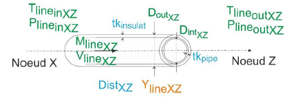

```python
Image(filename="Capture5.png")
```

```python
# Pertes thermiques (ici négligées car T_in = T_out)
def loss_linePC_rule(model,i,j):
    """Pertes thermiques sur les conduites entre producteur et consommateur - ALLER"""
    return model.T_linePC_out[i,j] == model.T_linePC_in[i,j]
model.loss_linePC = Constraint(model.i, model.j,rule=loss_linePC_rule)

def loss_lineCP_rule(model,j,i):
    """Pertes thermiques sur les conduites entre producteur et consommateur - RETOUR"""
    return model.T_lineCP_out[j,i] == model.T_lineCP_in[j,i]
model.loss_lineCP = Constraint(model.j, model.i,rule=loss_lineCP_rule)

def loss_lineCC_parallel_rule(model,j,o):
    """Pertes thermiques sur les conduites entre consommateur - ALLER"""
    return model.T_lineCC_parallel_out[j,o] == model.T_lineCC_parallel_in[j,o]
model.loss_lineCC_parallel = Constraint(model.j, model.o,rule=loss_lineCC_parallel_rule)

def loss_lineCC_return_rule(model,o,j):
    """Pertes thermiques sur les conduites entre consommateurs - RETOUR"""
    return model.T_lineCC_return_out[o,j] == model.T_lineCC_return_in[o,j]
model.loss_lineCC_return = Constraint(model.o, model.j,rule=loss_lineCC_return_rule)
```

### Puissance requise à l'échangeur

Description en docstring ou dans le code

```python
# Contrainte à l'échangeur
def contrainte_appro_rule(model,j):
    """La puissance calculée à l'échangeur doit être égale à celle requise rentrée par l'utilisateur"""
    return model.H_hx[j] == model.H_req[j]
model.contrainte_appro = Constraint(model.j, rule=contrainte_appro_rule)
```

### Equation des termes de la fonction coût

```python
# Termes de la fonction coût
def cout_pompage_rule(model):
    """Coût de pompage"""
    return model.C_pump == 1.e-6*model.f_opex_pump*model.C_pump_unit*model.period*sum(model.P_pump[i]*model.M_prod_tot[i] for i in model.i)*model.Eff_pump/model.rho
model.cout_pompage = Constraint(rule=cout_pompage_rule)

def cout_heat_rule(model):
    """Coût de la chaleur livrée"""
    return model.C_heat == 1.e-6 * model.period * sum(model.f_opex[k] * model.C_heat_unit[k] * model.H_inst[i,k] for i in model.i for k in model.k)
model.cout_heat = Constraint(rule=cout_heat_rule)

def cout_puissance_rule(model):
    """Coût de la puissance installée en chaufferie"""
    return model.C_Hinst == 1.e-6 * model.f_capex * sum(model.C_Hprod_unit[k] * model.H_inst[i,k] for i in model.i for k in model.k)
model.cout_puissance = Constraint(rule=cout_puissance_rule)

def cout_echangeur_rule(model):
    """Coût des échangeurs"""
    return model.C_hx == 1.e-6*model.f_capex*sum(model.C_hx_unit_a*model.H_hx[j]+model.C_hx_unit_b for j in model.j)
model.cout_echangeur = Constraint(rule=cout_echangeur_rule)

def cout_canalisation_tuyau_rule(model):
    """Coût des tuyaux pré-isolés"""
    return model.C_pipe == 1.e-6* model.f_capex*(
    sum(model.L_PC[i,j]*(model.C_pipe_unit_a*model.Dint_PC[i,j]+model.C_pipe_unit_b) for i in model.i for j in model.j)
    + sum(model.L_CP[j,i]*(model.C_pipe_unit_a*model.Dint_CP[j,i]+model.C_pipe_unit_b) for j in model.j for i in model.i)
    + sum(model.L_CC_parallel[j,o]*(model.C_pipe_unit_a*model.Dint_CC_parallel[j,o]+model.C_pipe_unit_b) for j in model.j for o in model.o)
    + sum(model.L_CC_return[j,o]*(model.C_pipe_unit_a*model.Dint_CC_return[j,o]+model.C_pipe_unit_b) for j in model.j for o in model.o)
    )
model.cout_canalisation_tuyau = Constraint(rule=cout_canalisation_tuyau_rule)

def cout_canalisation_tranchee_rule(model):
    """Coût de tranchée"""
    return model.C_tr == 1.e-6* model.f_capex*(
    sum(model.C_tr_unit/2 * model.L_PC[i,j] for i in model.i for j in model.j)
    + sum(model.C_tr_unit/2 * model.L_CP[j,i] for j in model.j for i in model.i)
    + sum(model.C_tr_unit/2 * model.L_CC_parallel[j,o] for j in model.j for o in model.o)
    + sum(model.C_tr_unit/2 * model.L_CC_return[j,o] for j in model.j for o in model.o)
    )
model.cout_canalisation_tranchee = Constraint(rule=cout_canalisation_tranchee_rule)

def cout_canalisation_tot_rule(model):
    """Coût total de canalisation: tuyaux + tranchée"""
    return model.C_line_tot == model.C_pipe + model.C_tr
model.cout_canalisation_tot = Constraint(rule=cout_canalisation_tot_rule)
```

### Calcul de la longueur totale du réseau optimisé

Description en docstring ou dans le code

```python
# Longueur totale du réseau
def Ex_L_tot_rule(model):
    """Correspond à la somme de tous les tuyaux posés = 2 fois la longueur de tranchée car tuyau aller-retour"""
    return model.L_tot == sum(model.L_PC[i,j] for i in model.i for j in model.j) +(
                        sum(model.L_CP[j,i] for j in model.j for i in model.i)
                        + sum(model.L_CC_parallel[j,o]  for j in model.j for o in model.o)
                        + sum(model.L_CC_return[j,o]  for j in model.j for o in model.o)
                        )
model.Ex_L_tot = Constraint(rule=Ex_L_tot_rule)
```

## OBJECTIF

```python
#-----------------------------------------------------------------------------------------#
####################################### OBJECTIVE #########################################
#-----------------------------------------------------------------------------------------#

# Definition de la fonction objectif à minimiser
def objective_rule(model):
    """Sommes des termes coût"""
    return model.C_pump + model.C_heat + model.C_Hinst + model.C_hx + model.C_line_tot
model.objective = Objective(rule=objective_rule, sense=minimize)
```

## SOLVEUR

### Instance du modèle

```python
# Crée et affiche l'instance du modèle (récapitulatif des indices, paramètres, variables, objectifs, contraintes)
print('-'*60 + "\nPROBLEME/MODELE\n" + '-'*60)

instance = model.create_instance() # crée
instance.pprint() # affiche
```

[output not shown]

[output cut: 957 more lines]

[output not shown]

### Résolution

```python
# Résolution du problème
if __name__ == '__main__': # ne pas lancer si appel depuis l'extérieur

    print('-'*60 + "\nRESOLUTION\n" + '-'*60)

    from pyomo.opt import SolverFactory

    # choix du solveur
    opt = SolverFactory('ipopt')

    # options [cf https://www.coin-or.org/Ipopt/documentation/node42.html]
    opt.options['tol'] = 1e-3           # defaut: 1e-8
    opt.options['max_iter']           # defaut: 3000
    opt.options['max_cpu_time']           # defaut: 1e+6
    opt.options['dual_inf_tol']           # defaut = 1
    opt.options['constr_viol_tol']           # defaut = 0.0001
    opt.options['compl_inf_tol']           # defaut = 0.0001
    opt.options['acceptable_tol']           # defaut = 1e-6
    opt.options['acceptable_iter']           # defaut = 15
    opt.options['acceptable_constr_viol_tol']           # defaut = 0.01
    opt.options['acceptable_dual_inf_tol']           # defaut = 1e+10
    opt.options['acceptable_compl_inf_tol']           # defaut = 0.01
    opt.options['acceptable_obj_change_tol']           # defaut = 1e+20
    opt.options['diverging_iterates_tol']           # defaut = 1e+20

    # optimisation
    results = opt.solve(model,tee=True, keepfiles=False) # [tee] affichage itération [keepfiles] création des fichier .nl/.sol/.log
```

```
------------------------------------------------------------
RESOLUTION
------------------------------------------------------------
Ipopt 3.11.1: tol=0.001


This program contains Ipopt, a library for large-scale nonlinear optimization.
 Ipopt is released as open source code under the Eclipse Public License (EPL).
         For more information visit http://projects.coin-or.org/Ipopt

NOTE: You are using Ipopt by default with the MUMPS linear solver.
      Other linear solvers might be more efficient (see Ipopt documentation).


This is Ipopt version 3.11.1, running with linear solver mumps.

Number of nonzeros in equality constraint Jacobian...:      190
Number of nonzeros in inequality constraint Jacobian.:       90
Number of nonzeros in Lagrangian Hessian.............:       53

Total number of variables............................:      112
                     variables with only lower bounds:        8
                variables with lower and upper bounds:      104
                     variables with only upper bounds:        0
Total number of equality constraints.................:       72
Total number of inequality constraints...............:       60
        inequality constraints with only lower bounds:       17
   inequality constraints with lower and upper bounds:       16
        inequality constraints with only upper bounds:       27

iter    objective    inf_pr   inf_du lg(mu)  ||d||  lg(rg) alpha_du alpha_pr  ls
   0 4.9999950e-002 2.20e+002 1.00e+000  -1.0 0.00e+000    -  0.00e+000 0.00e+000   0
   1 5.0019962e-002 2.20e+002 2.23e+001  -1.0 1.82e+003    -  4.50e-005 4.92e-005h  1
   2 5.0094152e-002 2.20e+002 1.14e+001  -1.0 1.06e+003    -  4.85e-005 9.99e-005f  1
   3r5.0094152e-002 2.20e+002 9.99e+002   2.3 0.00e+000    -  0.00e+000 2.70e-007R  6
   4r6.2331075e-002 2.20e+002 9.99e+002   2.3 1.30e+003    -  6.10e-005 1.45e-004f  1
   5r7.1799812e-002 2.20e+002 9.99e+002   2.3 1.36e+003    -  1.18e-003 1.54e-004f  1
   6r5.1047132e-001 2.19e+002 9.84e+002   2.3 6.16e+003    -  1.34e-003 1.50e-002f  1
   7r5.1477836e-001 2.19e+002 9.84e+002   2.3 1.54e+004  -2.0 7.55e-004 4.37e-004f  1
   8r5.4464075e-001 2.18e+002 9.79e+002   2.3 2.01e+003    -  6.28e-002 4.41e-003f  1
```

[output cut: 151 more lines]

```
Complementarity.........:  1.0340136233546904e-005   1.0340136233546904e-005
Overall NLP error.......:  8.3633739393462747e-005   8.3633739393462747e-005


Number of objective function evaluations             = 491
Number of objective gradient evaluations             = 113
Number of equality constraint evaluations            = 491
Number of inequality constraint evaluations          = 491
Number of equality constraint Jacobian evaluations   = 148
Number of inequality constraint Jacobian evaluations = 148
Number of Lagrangian Hessian evaluations             = 139
Total CPU secs in IPOPT (w/o function evaluations)   =      0.501
Total CPU secs in NLP function evaluations           =      0.033

EXIT: Optimal Solution Found.
```

## SOLUTION

```python
#-----------------------------------------------------------------------------------------#
###################################### SOLUTION ########################################
#-----------------------------------------------------------------------------------------#

## Ecriture et affichage de la solution
print('\n' + '-'*60 + "\nSOLUTION\n" + '-'*60)
def pyomo_postprocess(options=None, instance=None, results=None):
    instance.solutions.load_from(results)
    # ecriture
    with open('./Solution.txt', 'w') as f:
        f.write ('{} {}\n'.format("///Objective///\n", round(value(instance.objective),2)))
        f.write('///Variables///\n')
        for v in instance.component_objects(Var, active=True):
            varobject = getattr(instance, str(v))
            for index in varobject:
                f.write ('{} {} {}\n'.format(v,[index],round(varobject[index].value,3)))

pyomo_postprocess(None, model, results)

print('Ecriture du fichier solution.txt: ok')

    # affichage
print('Affichage de la solution:')

display(model)
```

```
------------------------------------------------------------
SOLUTION
------------------------------------------------------------
Ecriture du fichier solution.txt: ok
Affichage de la solution:
Model unknown

  Variables:
    V_linePC : vitesses conduites producteurs-consommateurs = ALLER
        Size=2, Index=V_linePC_index
        Key          : Lower : Value                  : Upper : Fixed : Stale : Domain
        ('P1', 'C1') :     0 :     1.7006864888401347 :     3 : False : False :  Reals
        ('P1', 'C2') :     0 : 1.2957917667920809e-08 :     3 : False : False :  Reals
    V_lineCP : vitesses conduites consommateurs-producteurs = RETOUR
        Size=2, Index=V_lineCP_index
        Key          : Lower : Value                  : Upper : Fixed : Stale : Domain
        ('C1', 'P1') :     0 :      1.700686482444722 :     3 : False : False :  Reals
        ('C2', 'P1') :     0 : 1.2957921692018654e-08 :     3 : False : False :  Reals
    V_lineCC_parallel : vitesses conduites consommateurs-consommateurs ALLER
        Size=4, Index=V_lineCC_parallel_index
        Key          : Lower : Value                  : Upper : Fixed : Stale : Domain
        ('C1', 'C1') :     0 : 1.2958025290401905e-08 :     3 : False : False :  Reals
        ('C1', 'C2') :     0 :     1.5349478226592232 :     3 : False : False :  Reals
        ('C2', 'C1') :     0 : 1.2958420980948172e-08 :     3 : False : False :  Reals
        ('C2', 'C2') :     0 : 1.2958025290401905e-08 :     3 : False : False :  Reals
    V_lineCC_return : vitesses conduites consommateurs-consommateurs RETOUR
        Size=4, Index=V_lineCC_return_index
        Key          : Lower : Value                  : Upper : Fixed : Stale : Domain
        ('C1', 'C1') :     0 : 1.2958025290401905e-08 :     3 : False : False :  Reals
        ('C1', 'C2') :     0 : 1.2959053849485992e-08 :     3 : False : False :  Reals
        ('C2', 'C1') :     0 :     1.5349478200805653 :     3 : False : False :  Reals
        ('C2', 'C2') :     0 : 1.2958025290401905e-08 :     3 : False : False :  Reals
    Dint_PC : diamètres intérieurs conduites producteurs-consommateurs = ALLER
        Size=2, Index=Dint_PC_index
        Key          : Lower : Value               : Upper : Fixed : Stale : Domain
        ('P1', 'C1') :  0.01 : 0.12736339061840352 :  0.25 : False : False :  Reals
        ('P1', 'C2') :  0.01 : 0.10369999999999999 :  0.25 : False : False :  Reals
    Dint_CP : diamètres intérieurs conduites consommateurs-producteurs = RETOUR
        Size=2, Index=Dint_CP_index
        Key          : Lower : Value               : Upper : Fixed : Stale : Domain
```

[output cut: 482 more lines]

```
    cout_echangeur : Size=1
        Key  : Lower : Body : Upper
        None :   0.0 :  0.0 :   0.0
    cout_canalisation_tuyau : Size=1
        Key  : Lower : Body                  : Upper
        None :   0.0 : 8.673617379884035e-19 :   0.0
    cout_canalisation_tranchee : Size=1
        Key  : Lower               : Body                : Upper
        None : 0.15848302848460863 : 0.15848302848460863 : 0.15848302848460863
    cout_canalisation_tot : Size=1
        Key  : Lower : Body : Upper
        None :   0.0 :  0.0 :   0.0
    Ex_L_tot : Size=1
        Key  : Lower : Body  : Upper
        None : 220.0 : 220.0 : 220.0
```